# Analyse des matchs d’aujourd’hui

Me

07 January, 2021

## Graphique

**En haut de la diagonale est bon, en dessous, c’est mauvais!**

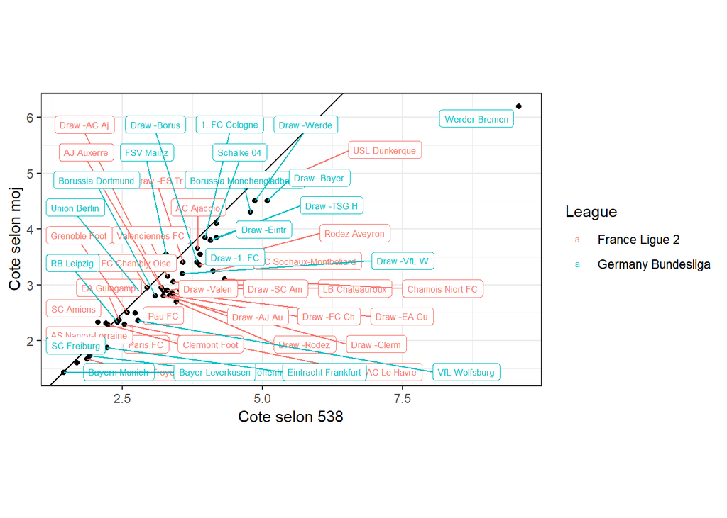

## Matchups à considérer

Tous les matchups dont la cote de MOJ est trop grosse selon 538

| League | GameName | Equipe à prendre | Cote - MOJ | Cote - 538 | Probabilité - MOJ | Probabilité - 538 |
| --- | --- | --- | --- | --- | --- | --- |
| France Ligue 2 | SC Amiens at Chamois Niort FC | SC Amiens | 2.33 | 2.06 | 42.9% | 48.5% |
| France Ligue 2 | Rodez Aveyron at AS Nancy-Lorraine | AS Nancy-Lorraine | 2.31 | 2.21 | 43.3% | 45.4% |
| France Ligue 2 | FC Chambly Oise at Pau FC | FC Chambly Oise | 2.95 | 2.94 | 33.9% | 34.0% |
| France Ligue 2 | Clermont Foot at FC Sochaux-Montbeliard | Clermont Foot | 2.29 | 2.24 | 43.7% | 44.7% |
| Germany Bundesliga | VfL Wolfsburg at Union Berlin | Union Berlin | 2.90 | 2.79 | 34.5% | 35.9% |
| Germany Bundesliga | Eintracht Frankfurt at FSV Mainz | FSV Mainz | 3.55 | 3.28 | 28.2% | 30.5% |

## Combinaisons intéressantes

L’idée ici est de sortir 3 combinaisons intéressantes :

- Une qui maximimise la cote (implique généralement une moins grande probabilité)
- Une qui maximise la probabilité (impliqué généralement une moins grande cote)
- Une qui fait un compromis entre les 2

On se limite à regarder les combinaisons de taille 3 et de taille 2

### Combinaisons de taille 2

| Index | Teams | Probabilité - 538 | Probabilité - MOJ | Cote - MOJ | Espérance de gain |
| --- | --- | --- | --- | --- | --- |
| Top 2 - Meilleure Cote | Schalke 04-FSV Mainz | 7.3% | 6.9% | 14.55 | 0.99 |
| Top 2 - Meilleure Cote | Draw -Werde-FSV Mainz | 6.3% | 6.3% | 15.97 | 0.94 |
| Top 2 - Meilleure Esperance | SC Amiens-FSV Mainz | 14.8% | 12.1% | 8.27 | 1.08 |
| Top 2 - Meilleure Esperance | Union Berlin-FSV Mainz | 10.9% | 9.7% | 10.29 | 1.02 |
| Top 2 - Meilleure Prob | SC Amiens-Bayer Leverkusen | 33.5% | 30.0% | 3.33 | 0.78 |
| Top 2 - Meilleure Prob | AS Nancy-Lorraine-Bayer Leverkusen | 31.3% | 30.3% | 3.30 | 0.72 |

### Combinaisons de taille 3

Index

Teams

Probabilité - 538

Probabilité - MOJ

Cote - MOJ

Espérance de gain

Top 2 - Meilleure Cote

1. FC Cologne-Schalke 04-FSV Mainz

1.8%

1.8%

56.04

1.01

Top 2 - Meilleure Cote

AC Ajaccio-Schalke 04-FSV Mainz

1.9%

1.9%

53.13

0.99

Top 2 - Meilleure Esperance

SC Amiens-Union Berlin-FSV Mainz

5.3%

4.2%

23.99

1.22

Top 2 - Meilleure Esperance

SC Amiens-AS Nancy-Lorraine-FSV Mainz

6.7%

5.2%

19.11

1.22

Top 2 - Meilleure Prob

SC Amiens-Bayern Munich-Bayer Leverkusen

19.9%

18.8%

5.33

0.86

Top 2 - Meilleure Prob

SC Amiens-TSG Hoffenheim-Bayer Leverkusen

17.5%

17.3%

5.76

0.83